# The power of RMarkdown + GitHub + Overleaf

These code block are where I keep all of my notes & working thoughts on figure generation and analyses. When you “Knit” the R Notebook, it converts this markdown file to either PDF or HTML. This format is useful in place of creating a powerpoint of your figures, you can integrate your code and annotations all in one! And send to others as a single document. However, one downside is - if your code takes awhile to process (large dataset/many iterations), it will take that much longer to knit. This can be frustrating when producing a final product. I would recommend working with the products of your analyses by importing files created in other scripts, instead of trying to generate everything in the Rmd. On importing the data product, just make sure to document VERY well what script generated it.

This first chunk is the setup chunk. Currently, this will not appear in your knitted document because of “include=FALSE” (i.e. do NOT include this chunk in the output pdf/html). You can always remove the “include=FALSE” argument from the brackets to make more transparent what was required for your notebook (i.e. include in the output pdf all packages used and information to set up your .Rmd.

**Here we do 4 things in the set up brackets:**

1. Designate this is R code (you can run other languages)
2. Load the built-in cars dataset
3. indicate global options are being set
4. indicate the include=FALSE, do NOT include this chunk in the knit document

**Then, set knitr options:** *Specifically, we tell knitr how to create figures and where to write them out (i.e. our repository!)*

**Then, we load any necessary packages used in the .Rmd**

Above, I changed the font (bold, italicized), but there are built-in ways to organize your document. Different headings, as seen below, are useful for guiding readers through a more “outlined” document.

# Yay for Plots!

## Using built-in R data & Base R

### Ooooooh aaaaaahhhh, in-line code

There are 50 records in the cars dataset.

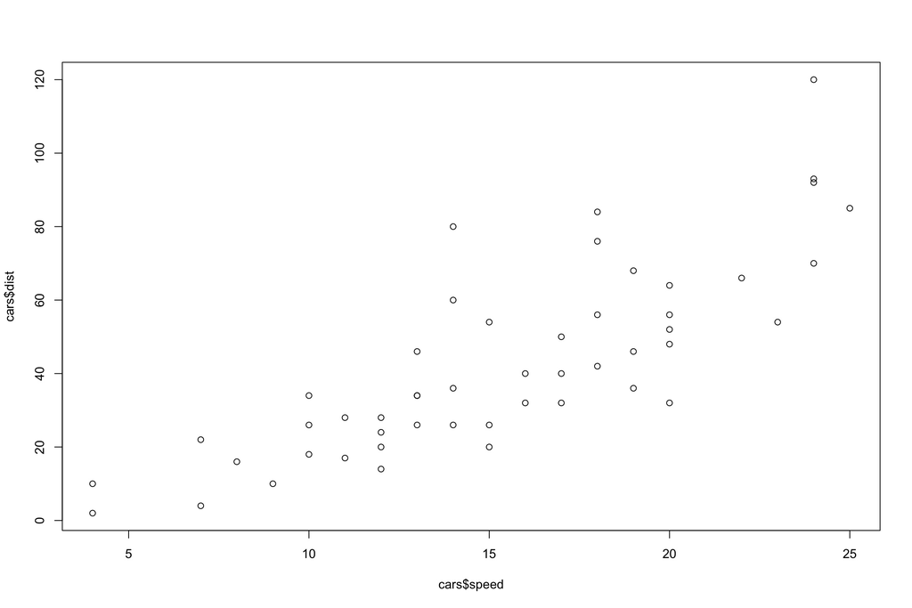

```r
#plot speed over distance
plot(cars$speed,cars$dist)
```

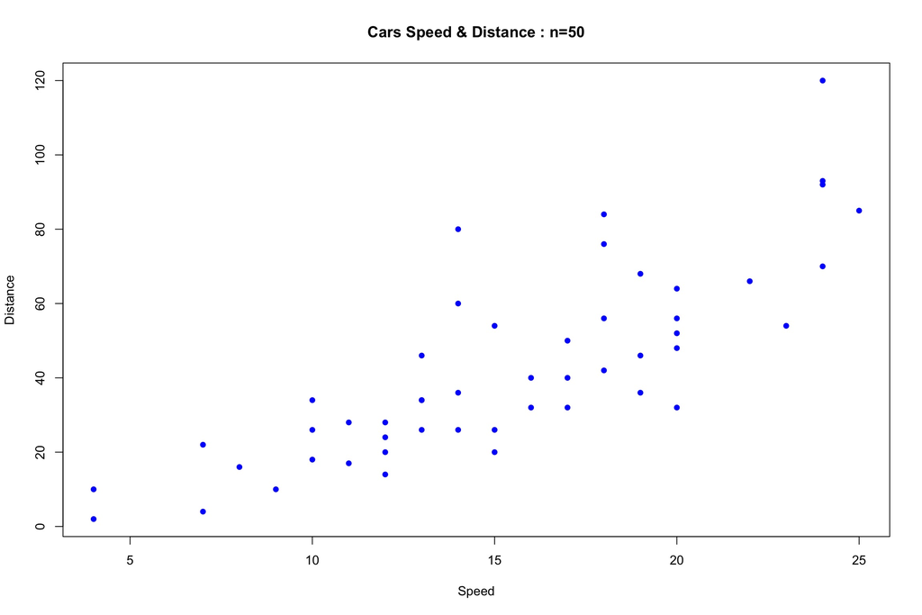

```r
#same plot, but improved! color, aces labels, symbol type specification, and title
plot(cars$speed,cars$dist,col="blue",xlab="Speed",ylab="Distance",pch=16,main="Cars Speed & Distance : n=50")
```

```r
#we can write out any dataframe as csv
write.csv(cars_df,"cars.csv")
```

# Plot Midwest Data

## Use ggplot

### Learn about plot strucure & themes!

Plots examples below and more from this website:

http://r-statistics.co/Top50-Ggplot2-Visualizations-MasterList-R-Code.html#Bubble%20Plot

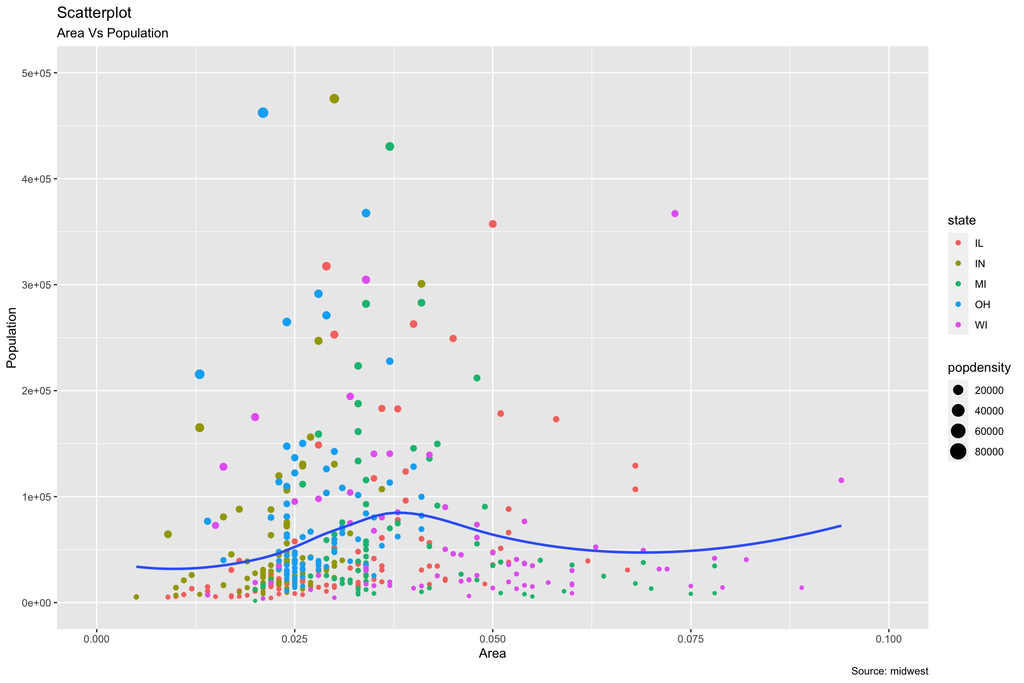

```r
#specify midwest data from ggplot2 (may be redundant with loading it in the setup brackets?)
data("midwest", package = "ggplot2")

#specify as dataframe, this is a step I generally do, but is not always necessary
midwest_df<-as.data.frame(midwest)

# Creating a scatterplot w/ ggplot
gg <- ggplot(midwest, aes(x=area, y=poptotal)) + #plot with specifying data as x,y
  geom_point(aes(col=state, size=popdensity)) + #color the scatterplot by state and size the dots by popdensity
  geom_smooth(method="loess", se=F) + #loess = "smooth local regression"
  xlim(c(0, 0.1)) + #x-zaxis limits
  ylim(c(0, 500000)) + #y-axis limits
  labs(subtitle="Area Vs Population",  #specify all labels
       y="Population",
       x="Area",
       title="Scatterplot",
       caption = "Source: midwest")

#here we can plots or design elements together to create a new plot
#it doesn't plot the plot, until calling "plot" (below)
gg_themed<- gg +  theme_tufte()

plot(gg)
```

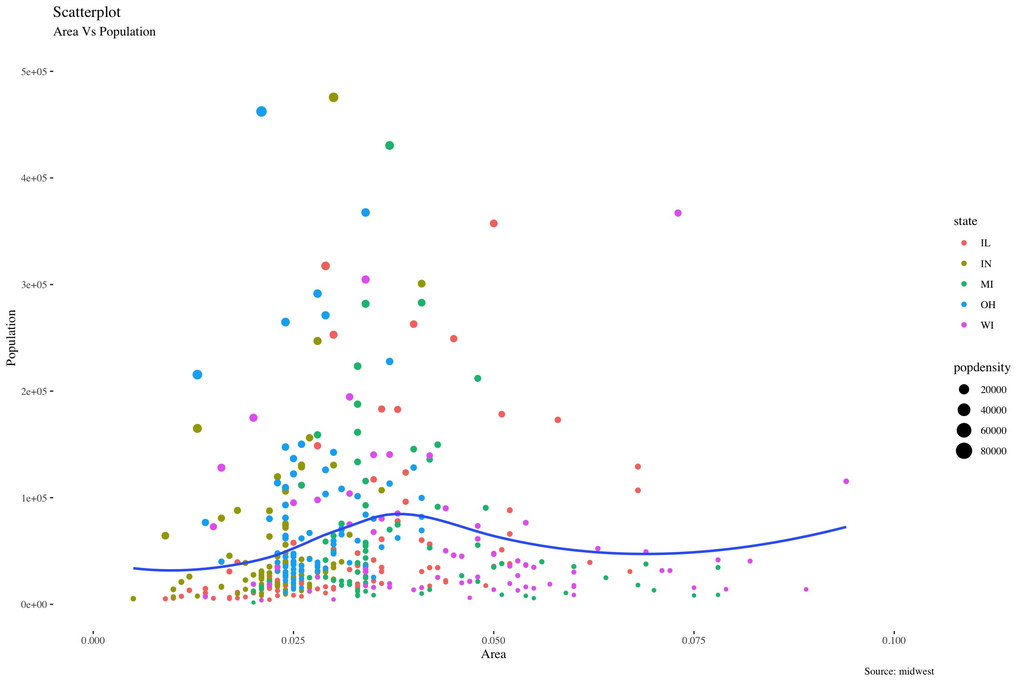

```r
plot(gg_themed)
```

# Some additional functionality with ggplot & Markdown

### Can create a variety of graphics

Again, this is a great place to leave notes,questions, or explanations about the figures in the chunk below. We all know we should write better figure captions or document our thoughts more often before we share a plot or have to explain it. This is a great place to write while it’s fresh on your mind!

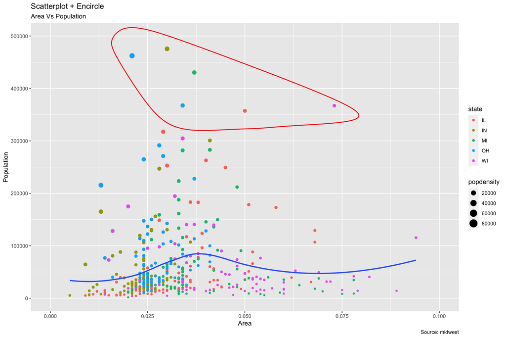

```r
#specifies when to use scientific notation
#if you want to read more, here's a useful explanation: https://stackoverflow.com/questions/25946047/how-to-prevent-scientific-notation-in-r
options(scipen = 999)
midwest_select <- midwest[midwest$poptotal > 350000 & #creating catagories for the data
                            midwest$poptotal <= 500000 &
                            midwest$area > 0.01 &
                            midwest$area < 0.1, ]

# Plot
ggplot(midwest, aes(x=area, y=poptotal)) +
  geom_point(aes(col=state, size=popdensity)) +   # draw points
  geom_smooth(method="loess", se=F) +
  xlim(c(0, 0.1)) +
  ylim(c(0, 500000)) +   # draw smoothing line
  geom_encircle(aes(x=area, y=poptotal),
                data=midwest_select,
                color="red",
                size=2,
                expand=0.08) +   # encircle
  labs(subtitle="Area Vs Population",
       y="Population",
       x="Area",
       title="Scatterplot + Encircle",
       caption="Source: midwest")
```

# To prove ggplot makes more than scatterplots

Annotations in an .Rmd do NOT take the place of commenting in line!

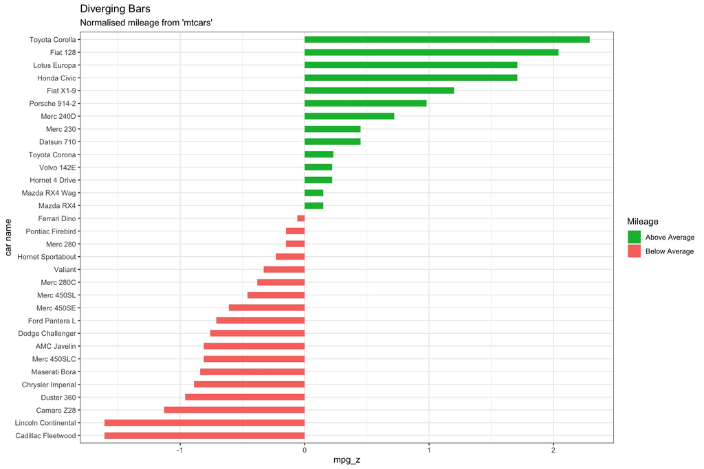

```r
library(ggplot2)
theme_set(theme_bw())

# Data Prep
data("mtcars")  # load data
mtcars$`car name` <- rownames(mtcars)  # create new column for car names
mtcars$mpg_z <- round((mtcars$mpg - mean(mtcars$mpg))/sd(mtcars$mpg), 2)  # compute normalized mpg
mtcars$mpg_type <- ifelse(mtcars$mpg_z < 0, "below", "above")  # above / below avg flag
mtcars <- mtcars[order(mtcars$mpg_z), ]  # sort
mtcars$`car name` <- factor(mtcars$`car name`, levels = mtcars$`car name`)  # convert to factor to retain sorted order in plot.

# Diverging Barcharts
ggplot(mtcars, aes(x=`car name`, y=mpg_z, label=mpg_z)) +
  geom_bar(stat='identity', aes(fill=mpg_type), width=.5)  +
  scale_fill_manual(name="Mileage",
                    labels = c("Above Average", "Below Average"),
                    values = c("above"="#00ba38", "below"="#f8766d")) +
  labs(subtitle="Normalised mileage from 'mtcars'",
       title= "Diverging Bars") +
  coord_flip()
```